# Lab 1 Hip Hop

From this we can see that the title “Hella Bling” will have a higher appeal in larger population areas.

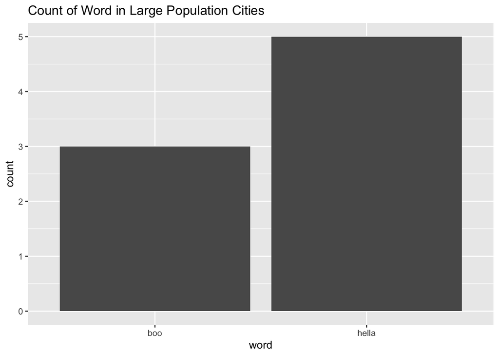

```r
city_pop <- clean_hiphop %>%
  select(word, city, county, fam1) %>%
  mutate(cat_city = case_when(
    city >= 0 & city < 300000 ~ "small",
    city >= 300000 & city < 500000 ~ "medium",
    city >500000 ~ "large")) %>%
  filter(word == "hotline" | word == "bling" | word == "boo" | word == "hella", fam1 != 0) %>%
  arrange(desc(city))

city_pop %>%
  filter(cat_city == "large")%>%
  ggplot() +
  geom_bar(mapping = aes(x = word)) +
  labs(title = "Count of Word in Large Population Cities")
```

3. Aubrey’s true life dream is to collaborate with his fellow Canadian musician Justin Bieber. Luckily, he knows that Bieber himself was one of the subjects in this study! You know that Bieber is a white male, aged 17-23 at the time of the study, from a relatively small town (10,000-60,000 people) in Ontario. Determine which subject is secretly Bieber, and justify your answer.

From this data it is concluded that Justin Bieber is subject p17. This was found by first filtering the data to the characteristics that fit Justin Biever (age range, gender, sex, city population). From here, I arranged the remaining data in order of the bieber category. Thus, Justin Bieber would be the subject that knows the most Bieber songs in this filtered set of data. This is how I concluded that he was p17.

```r
Bieberdata <- cleaner_hiphop %>%
  select(age, sex, city, bieber, subj) %>%
  filter(age <= 23, age >= 17, sex == "Male", city <= 60000, city >= 10000) %>%
  arrange(desc(bieber))
Bieberdata
```

```
## # A tibble: 15 x 5
##      age sex    city bieber subj
##    <dbl> <chr> <dbl>  <dbl> <chr>
##  1    18 Male  56377    5   p17
##  2    21 Male  59180    2   p183
##  3    18 Male  17056    2   p84
##  4    18 Male  24545    2   p119
##  5    19 Male  24105    2   p74
##  6    20 Male  23739    2   p178
##  7    18 Male  50804    2   p32
##  8    18 Male  19657    1.5 p180
##  9    19 Male  19657    1   p169
## 10    20 Male  10465    1   p138
## 11    18 Male  31008    1   p55
## 12    17 Male  19391    1   p28
## 13    23 Male  57345    1   p121
## 14    19 Male  45561    1   p148
## 15    18 Male  33220    1   p141
```

4. Use the dataset to suggest a track listing (11 song titles) for Aubrey’s next album with the Biebs. Explain your thought process and corresponding code.

The 11 title suggestions are CP time, dap, dukey rope, plex, road dog, saditty, talking jazz, boughie, cop my steezy, good hair, and straight cash. The code I used for this is filtered to true hiphop fans which I have classified at scoring 7 or greater and then words that these hiphop fans are familiar with. I used the binary fam1 to distinguish if they are familiar or not. Then I grouped the words by the mean bieber category. I did this to see the average bieber score for each word. Then I arranged the data in order of how high the bieber category scored. I based this off of the fact that Aubrey wants to work with Justin Bieber for his next album to select the title.

```r
clean_hiphop %>%
  select(hiphop, word, fam1, bieber, pop) %>%
  filter(hiphop >= 7, fam1 != 0)%>%
  group_by(word) %>%
  summarise(meanbieber = mean(bieber)) %>%
  arrange(desc(meanbieber))
```

```
## # A tibble: 59 x 2
##    word          meanbieber
##    <chr>              <dbl>
##  1 CP time                6
##  2 dap                    6
##  3 dukey rope             6
##  4 plex                   6
##  5 road dog               6
##  6 saditty                6
##  7 talking jazz           6
##  8 boughie                5
##  9 cop my steezy          5
## 10 good hair              5
## # … with 49 more rows
```